# Assignment 2a

Damilare Olaleye

August 29, 2019

1. Create a vector “ages”" containing the age (at inauguration) of the ten most recent Presidents. Using the names function add last names to the values of this vector.

```r
ages <- c(70, 47, 54, 46, 64, 69, 52, 61, 56, 55)
names(ages) <- c("Trump", "Obama", "Bush", "Clinton", "Bush", "Reagan", "Carter", "Ford", "Nixon", "Johnson")

ages
```

```
##   Trump   Obama    Bush Clinton    Bush  Reagan  Carter    Ford   Nixon
##      70      47      54      46      64      69      52      61      56
## Johnson
##      55
```

2. Create another vector “year”" containing the year at inauguration of these ten Presidents.

```r
year <- c(2017, 2009, 2001, 1993, 1989, 1981, 1977, 1974, 1969, 1963)
year
```

```
##  [1] 2017 2009 2001 1993 1989 1981 1977 1974 1969 1963
```

3. Find the mean, min, and maximum age of these 10 Presidents.

```r
mean_age <- mean(ages)
min_age <- min(ages)
max_age <- max(ages)

mean_age
```

```
## [1] 57.4
```

```r
min_age
```

```
## [1] 46
```

```r
max_age
```

```
## [1] 70
```

4. Convert these ages to months using a vector operation – call the new vector “ages.months”.

```r
ages.months <- 12*ages
ages.months
```

```
##   Trump   Obama    Bush Clinton    Bush  Reagan  Carter    Ford   Nixon
##     840     564     648     552     768     828     624     732     672
## Johnson
##     660
```

5. Using logical operations, create a new vector “age.young” with the ages of the Presidents younger than 50.

```r
age.young <- ages < 50
age.young
```

```
##   Trump   Obama    Bush Clinton    Bush  Reagan  Carter    Ford   Nixon
##   FALSE    TRUE   FALSE    TRUE   FALSE   FALSE   FALSE   FALSE   FALSE
## Johnson
##   FALSE
```

6. Create a vector of the ages of the Presidents inaugurated after 1975.

```r
age_inaug_75 <- ages [year > 1975]
age_inaug_75
```

```
##   Trump   Obama    Bush Clinton    Bush  Reagan  Carter
##      70      47      54      46      64      69      52
```

7. Plot the inauguration year against the age for these 10 Presidents. Do you see any pattern in this graph?

```r
table(year, ages)
```

```
##       ages
## year   46 47 52 54 55 56 61 64 69 70
##   1963  0  0  0  0  1  0  0  0  0  0
##   1969  0  0  0  0  0  1  0  0  0  0
##   1974  0  0  0  0  0  0  1  0  0  0
##   1977  0  0  1  0  0  0  0  0  0  0
##   1981  0  0  0  0  0  0  0  0  1  0
##   1989  0  0  0  0  0  0  0  1  0  0
##   1993  1  0  0  0  0  0  0  0  0  0
##   2001  0  0  0  1  0  0  0  0  0  0
##   2009  0  1  0  0  0  0  0  0  0  0
##   2017  0  0  0  0  0  0  0  0  0  1
```

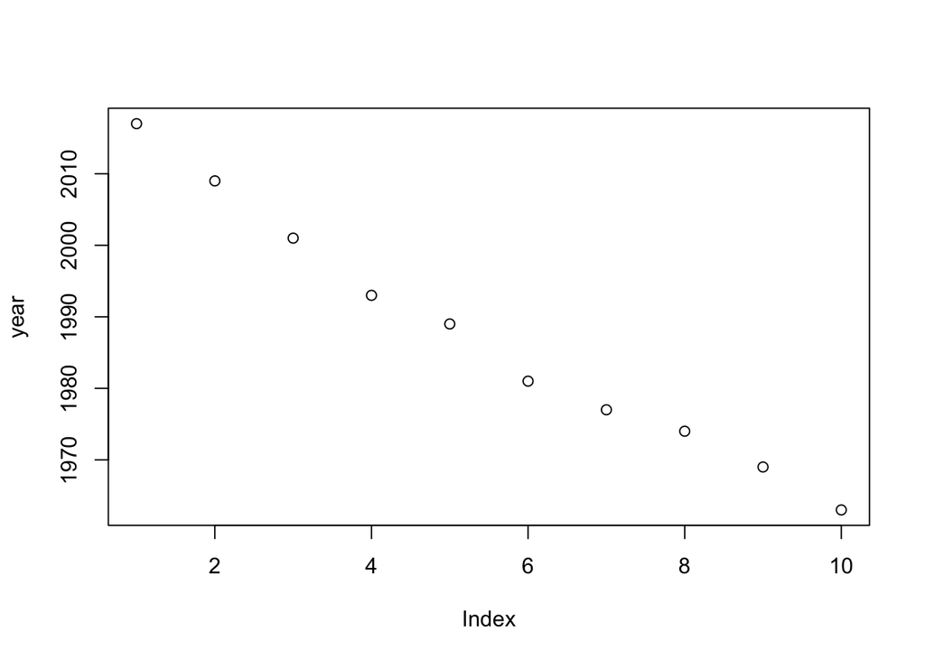

```r
plot(year)
```

8. Collect the writing hand (“L” or “R”) for all students in this class. Also collect the gender (“M” or “W”) for all students. Put the values in two character vectors “hand” and “gender”.

```r
gender <- c("M","M","F","F","M","M","F","M","F","F","M","M","F","F","M","M","F","M","M","M","F","M","M","M","F","M")
hand <- c("R","R","L","L","R","R","R","R","R","R","R","R","F","F","M","M","F","M","M","M","F","M","M","M","F","M")
```

9. Construct and display a frequency table of writing hand.

```r
table(hand,gender)
```

```
##     gender
## hand F M
##    F 5 0
##    L 2 0
##    M 0 9
##    R 3 7
```

10. Construct a graph of these writing hand frequencies.

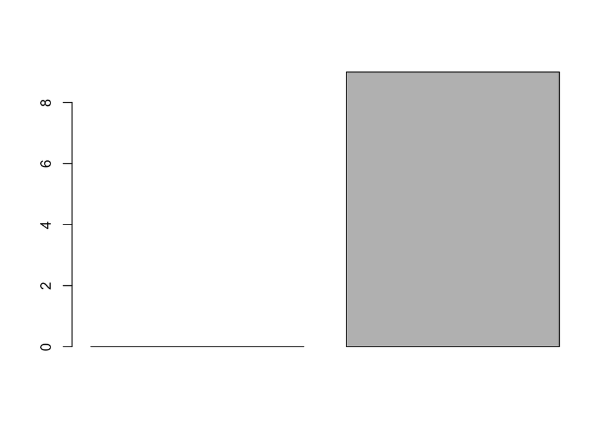

```r
barplot(c(0,9))
```

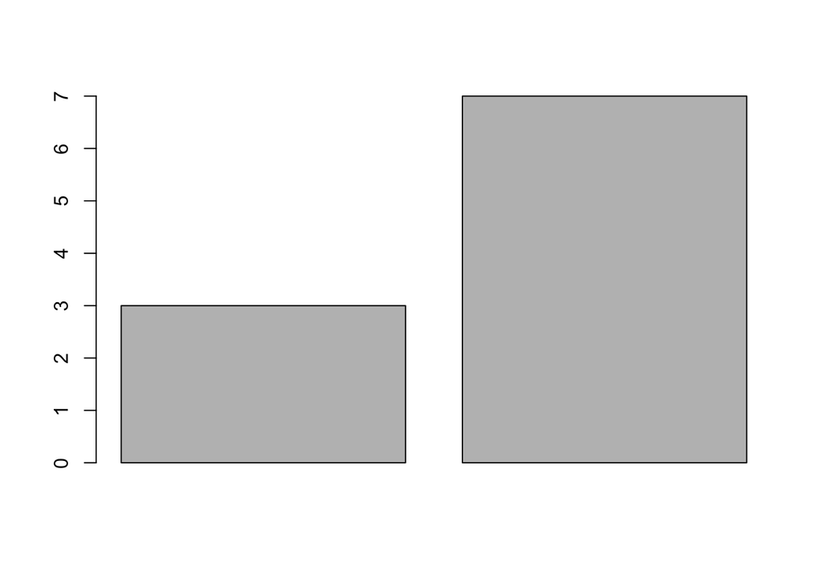

```r
barplot(c(3,7))
```

11. Using logical operations, create a vector of the writing hand of the women and another vector of the writing hand the men.

```r
women <- gender == "F"
women
```

```
##  [1] FALSE FALSE  TRUE  TRUE FALSE FALSE  TRUE FALSE  TRUE  TRUE FALSE
## [12] FALSE  TRUE  TRUE FALSE FALSE  TRUE FALSE FALSE FALSE  TRUE FALSE
## [23] FALSE FALSE  TRUE FALSE
```

```r
men <- gender == "M"
men
```

```
##  [1]  TRUE  TRUE FALSE FALSE  TRUE  TRUE FALSE  TRUE FALSE FALSE  TRUE
## [12]  TRUE FALSE FALSE  TRUE  TRUE FALSE  TRUE  TRUE  TRUE FALSE  TRUE
## [23]  TRUE  TRUE FALSE  TRUE
```

12. Find the high temperatures (in degrees Fahrenheit) of six cities (of your choice) – put these values in the vector “temp.F”.

```r
temp.F <- c(89, 64, 60, 69, 77, 80)
```

13. By performing a suitable operation, convert these temperatures to degrees Centigrade – put these in the vector “temp.C”.

```r
temp.C <- (temp.F - 32)*(5/9)
temp.C
```

```
## [1] 31.66667 17.77778 15.55556 20.55556 25.00000 26.66667
```

14. Round your calculations of temperatures Centigrade to the nearest tenth of a degree.

```r
round(temp.C, 1)
```

```
## [1] 31.7 17.8 15.6 20.6 25.0 26.7
```

15. Use vector operations, find the sum of (1 + x) ^ 2 as x takes on the integer values from 0 to 6.

```r
x = c(0,1,2,3,4,5,6)
sum((1+x)^2)
```

```
## [1] 140
```

16. One can represent the constant e^2 as the infinite series

1 + 2 + 2 ^ 2 / 2! + 2 ^ 3 / 3! + …

Use R to confirm this result.

```r
x <- 0:1000
sum(1/2 ^ x)
```

```
## [1] 2
```